# skyscapeR: Data Analysis and Visualization for Skyscape Archaeology

## 5. Other bits and bobs

`skyscapeR` includes many other helpful functions for analysis of orientations and their potential skyscape relations. Below they are mentioned only briefly, explaining their purpose. Remember to explore the full range of their parameters by using the help facility `?`.

### 5.1 Finding Celestial Targets

```r
findTargets(c(-25,-18), c(-2499,-1749))
```

```
#> $solar
#>                name   min.dec  max.dec           date1 date2
#> 1 december solstice -23.97662 -23.8981          21 Dec  <NA>
#> 2       sunrise/set -25.00000 -18.0000 10 Nov - 29 Jan  <NA>
#>
#> $lunar
#>                           name   min.dec  max.dec
#> 1 southern minor lunar extreme -18.68662 -18.6081
#>
#> $stellar
#>              name Bayer  vmag   min.dec   max.dec
#> 1          Sirius alCMa -1.46 -20.83266 -18.74915
#> 2           Rigel beOri  0.13 -23.18767 -19.54810
#> 3          Shaula laSco  1.62 -24.98490 -21.01297
#> 4  Kaus Australis epSgr  1.85 -25.96735 -22.35697
#> 5          Mirzam beCMa  1.97 -25.86732 -23.22182
#> 6           Saiph kaOri  2.06 -21.62401 -18.35720
#> 7           Nunki siSgr 2.067 -20.96992 -17.81015
#> 8          Kakkab alLup 2.286 -27.54586 -23.46907
#> 9             Wei epSco  2.29 -19.57299 -15.43774
#> 10                etCen  2.31 -22.21781 -18.15352
#> 11         Girtab kaSco 2.386 -27.39297 -23.44953
```

If one wants to look at more stars one needs only change the `max.mag` parameter as follows:

```r
findTargets(c(-25,-18), c(-2499,-1749), max.mag=3)
```

```
#> $solar
#>                name   min.dec  max.dec           date1 date2
#> 1 december solstice -23.97662 -23.8981          21 Dec  <NA>
#> 2       sunrise/set -25.00000 -18.0000 10 Nov - 29 Jan  <NA>
#>
#> $lunar
#>                           name   min.dec  max.dec
#> 1 southern minor lunar extreme -18.68662 -18.6081
#>
#> $stellar
#>              name   Bayer  vmag   min.dec   max.dec
#> 1          Sirius   alCMa -1.46 -20.83266 -18.74915
#> 2           Rigel   beOri  0.13 -23.18767 -19.54810
#> 3          Shaula   laSco  1.62 -24.98490 -21.01297
#> 4  Kaus Australis   epSgr  1.85 -25.96735 -22.35697
```

[output cut: 21 more lines]

### 5.2 Star Phases and Seasonality

To estimate the phases, events and/or seasonality of stars, the function `star.phases` can be used. It works as follows, for the location of Cairo, the year 3000 BC, and a horizon altitude of 2:

```r
sp <- star.phases('Sirius', -2999, loc=c(30.0, 31.2, 25), alt.hor=2)
```

One can then check the star’s phase type, events and seasons by simply typing:

```r
sp$metadata$type
```

```
#> [1] "arising and lying hidden"
```

```r
sp$metadata$events
```

```
#>               event      day
#> 1 acronycal setting April 14
#> 2   heliacal rising  June 19
```

```r
sp$metadata$seasons
```

[output not shown]

These can be visualized using:

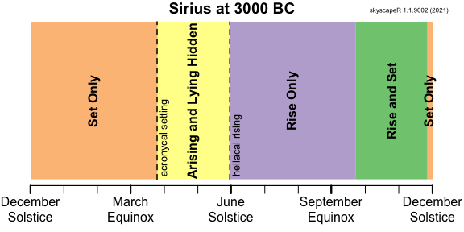

```r
plot(sp)
```

### 5.3 Planetarium

A simplistic sketch of the sky can be produced (for example, for publications) using `sky.sketch`. It accurately plots the position of sun, moon, planets and brightest stars against a given horizon and for a particular time. The example below is for a location in Portugal at 9.30am on the 7th of January 2019. Notice the exaggerated yellow circle for the sun and white circle for the moon.

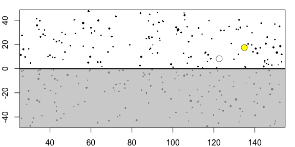

```r
sky.sketch(time='2019/01/07 09:30', loc=c(35,-8,100))
```